# Flight delay Analysis and Prediction

Problem Statement:

Air travel is becoming increasingly complex with multiple variables impacting the same. The flight delay is one of such variables impacts carrier, Airport, and passenger and may result in significant commercial loss or reputation loss to all the stakeholders and thus huge cost on the economy. Thus, prediction of delay is crucial not only from viewpoint of a customer from the time management perspective and carrier for retention of customer faith but also from Airport point of view for managing the traffic more efficiently to optimize the number of arriving flights by appropriate adjustment of schedules. The contribution of weather conditions has been identified to be a very important contributor to these delays. The historical data containing scheduled departure and arrival times, date, origin, destination and also weather data is available and the data scientists can predict if the delay can happen or not using the flight data and aviation weather data for a specific flight.

Every single flight is observed as per their scheduled departure and arrival timestamps, to record the details of trips made, traffic conditions, etc. Flight details like Origin, destination, date of flight, scheduled departure and scheduled arrival timestamps etc. Weather stations data details like station id along with it’s linked AirportID, ground height etc. Hourly aviation weather conditions data also provided for 2 years etc. Origin, Destination details in-flight data can be mapped to the AirportID in other datasets.

# The objective of this project:

1. To predict the Flight that is it delayed or not by the help of Weather conditions given as weather Hourly Data and Weather Hpd Data, Station conditions given as all Station Data.
2. To predict the Flight Analysis using ML Algorithms.
3. Providing Business solution as per features that have highest impact on the Flight Delay.

Data Description:

```python
import os
import pandas as pd
#setting current directory
os.chdir("/home/2386B49/cluster/2004/hourly")
```

# Set Directories and read csv files

```python
#reading weather hour data
weather_hour_data = pd.concat([pd.read_table(f , sep=",", encoding='unicode_escape',

                      na_values="'', '#N/A', '#N/A N/A', '#NA', '-1.#IND', '-1.#QNAN', '-NaN', '-nan', '1.#IND', '1.#QNAN', 'N/A', 'NA', 'NULL', 'NaN', 'n/a', 'nan', 'null', '?', '#'")

                                 for f in os.listdir("/home/2386B49/cluster/2004/hourly")], ignore_index = True)
```

```python
#reading weather hpd data

os.chdir("/home/2386B49/cluster/2004/hpd")
weather_hpd_data = pd.concat([pd.read_table(f , sep=",", encoding='unicode_escape',

                      na_values="'', '#N/A', '#N/A N/A', '#NA', '-1.#IND', '-1.#QNAN', '-NaN', '-nan', '1.#IND', '1.#QNAN', 'N/A', 'NA', 'NULL', 'NaN', 'n/a', 'nan', 'null', '?', '#'")

                                 for f in os.listdir("/home/2386B49/cluster/2004/hpd")], ignore_index = True)
```

```python
#read Flight train data
os.chdir("/home/2386B49/cluster")
Flight_train=pd.read_csv("FlightDelay_Train-1550042794911.csv")
```

```python
#read all station data
all_station_data= pd.read_csv("AllStationsData_PHD.txt",delimiter="|")
```

# view and check shape of all data frames

```python
weather_hour_data.head(2)
```

|  | WeatherStationID | YearMonthDay | Time | SkyConditions | Visibility | DBT | DewPointTemp | RelativeHumidityPercent | WindSpeed | WindDirection | WindGustValue | StationPressure |
| --- | --- | --- | --- | --- | --- | --- | --- | --- | --- | --- | --- | --- |
| 0 | 3034 | 20040101 | 10 | OVC095 | 10SM | 30.0 | 7.0 | 38.0 | 0 | 000 | 0.0 | 30.10 |
| 1 | 3035 | 20040101 | 10 | SCT110 | 10SM | 43.0 | 18.0 | 37.0 | 0 | 000 | 0.0 | 30.07 |

```python
weather_hour_data.shape
```

```
(11516906, 12)
```

```python
weather_hpd_data.head(2)
```

|  | WeatherStationID | YearMonthDay | Time | HourlyPrecip |
| --- | --- | --- | --- | --- |
| 0 | 3034 | 20040101 | 10 | 0.0 |
| 1 | 3035 | 20040101 | 10 | 0.0 |

```python
weather_hpd_data.shape
```

```
(12107407, 4)
```

```python
Flight_train.head(2)
```

|  | FlightNumber | Year | Month | DayofMonth | DayOfWeek | ScheduledDepTime | ScheduledArrTime | ScheduledTravelTime | Origin | Destination | Distance | ActualArrivalTimeStamp |
| --- | --- | --- | --- | --- | --- | --- | --- | --- | --- | --- | --- | --- |
| 0 | BOS_CLE_29089 | 2004 | 9 | 20 | 1 | 1000 | 1154 | 114 | BOS | CLE | 563 | 20/09/04 11:54 |
| 1 | CLE_ATL_44346 | 2004 | 11 | 19 | 5 | 1440 | 1634 | 114 | CLE | ATL | 554 | 19/11/04 18:55 |

```python
Flight_train.shape
```

```
(7861, 12)
```

```python
all_station_data.head(2)
```

|  | WeatherStationID | AirportID | GroundHeight | StationHeight | BarometerHeight | Latitude | Longitude | TimeZone |
| --- | --- | --- | --- | --- | --- | --- | --- | --- |
| 0 | 3011 | TEX | 0 | 0 | 0 | 37.57 | -107.55 | +7 |
| 1 | 3012 | SKX | 0 | 0 | 0 | 36.28 | -105.40 | +7 |

```python
all_station_data.shape
```

```
(1744, 8)
```

# merge hourly and hpd data into one data frame, merge on 'WeatherStationID','YearMonthDay','Time'

```python
weather = pd.merge(weather_hour_data,weather_hpd_data ,how='left', left_on=['WeatherStationID','YearMonthDay','Time'], right_on = ['WeatherStationID','YearMonthDay','Time'])
```

# merge weather and all station data into one data frame, merge on 'WeatherStationID'

```python
station_weather= pd.merge(all_station_data,weather,how="left",left_on=["WeatherStationID"],right_on=["WeatherStationID"])
```

```python
station_weather.head(2)
```

|  | WeatherStationID | AirportID | GroundHeight | StationHeight | BarometerHeight | Latitude | Longitude | TimeZone | YearMonthDay | Time | SkyConditions | Visibility | DBT | DewPointTemp | RelativeHumidityPercent | WindSpeed | WindDirection | WindGustValue | StationPressure | HourlyPrecip |
| --- | --- | --- | --- | --- | --- | --- | --- | --- | --- | --- | --- | --- | --- | --- | --- | --- | --- | --- | --- | --- |
| 0 | 3011 | TEX | 0 | 0 | 0 | 37.57 | -107.55 | +7 | 20040101 | 1350.0 | FEW075 BKN090 | 10SM | 32.0 | 10.0 | 40.0 | 15 | 160 | 0.0 | 30.05 | 0.0 |
| 1 | 3011 | TEX | 0 | 0 | 0 | 37.57 | -107.55 | +7 | 20040101 | 1910.0 | BKN028 OVC033 | 10SM | 21.0 | 14.0 | 74.0 | 5 | VRB | 0.0 | 30.06 | 0.0 |

```python
station_weather.shape
```

```
(11513465, 20)
```

```python
#add column and remove old column
Flight_train["Day"]=Flight_train["DayofMonth"]
Flight_train = Flight_train.drop(["DayofMonth"],axis=1)
```

```python
#add all information of date month and year into one column
Flight_train["Date"]=pd.to_datetime(Flight_train[["Year","Month","Day"]])
```

```python
#replacing missing unique by near by information
station_weather.YearMonthDay[10590609] = "20040515"
```

# seprate year month and date

```python
station_weather['Date'] =  pd.to_datetime(station_weather['YearMonthDay'], format='%Y%m%d')
```

# convert to string

```python
station_weather['Date']= station_weather.Date.astype(str)
Flight_train['Date']= Flight_train.Date.astype(str)
```

# seprate hours from time and making new column of it

```python
station_weather["hours"] = station_weather["Time"].astype(str)
station_weather["Hours"] = station_weather["hours"].str[:2]
```

```python
station_weather.head(2)
```

|  | WeatherStationID | AirportID | GroundHeight | StationHeight | BarometerHeight | Latitude | Longitude | TimeZone | YearMonthDay | Time | ... | DewPointTemp | RelativeHumidityPercent | WindSpeed | WindDirection | WindGustValue | StationPressure | HourlyPrecip | Date | hours | Hours |
| --- | --- | --- | --- | --- | --- | --- | --- | --- | --- | --- | --- | --- | --- | --- | --- | --- | --- | --- | --- | --- | --- |
| 0 | 3011 | TEX | 0 | 0 | 0 | 37.57 | -107.55 | +7 | 20040101 | 1350.0 | ... | 10.0 | 40.0 | 15 | 160 | 0.0 | 30.05 | 0.0 | 2004-01-01 | 1350.0 | 13 |
| 1 | 3011 | TEX | 0 | 0 | 0 | 37.57 | -107.55 | +7 | 20040101 | 1910.0 | ... | 14.0 | 74.0 | 5 | VRB | 0.0 | 30.06 | 0.0 | 2004-01-01 | 1910.0 | 19 |

2 rows × 23 columns

```python
Flight_train['hours']= Flight_train['ScheduledDepTime'].astype(str)
Flight_train["Hours"] = Flight_train["hours"].str[:2]
```

```python
Flight_train.head(2)
```

|  | FlightNumber | Year | Month | DayOfWeek | ScheduledDepTime | ScheduledArrTime | ScheduledTravelTime | Origin | Destination | Distance | ActualArrivalTimeStamp | Day | Date | hours | Hours |
| --- | --- | --- | --- | --- | --- | --- | --- | --- | --- | --- | --- | --- | --- | --- | --- |
| 0 | BOS_CLE_29089 | 2004 | 9 | 1 | 1000 | 1154 | 114 | BOS | CLE | 563 | 20/09/04 11:54 | 20 | 2004-09-20 | 1000 | 10 |
| 1 | CLE_ATL_44346 | 2004 | 11 | 5 | 1440 | 1634 | 114 | CLE | ATL | 554 | 19/11/04 18:55 | 19 | 2004-11-19 | 1440 | 14 |

Merge Flight_train and station_weather

```python
final_train = pd.merge(Flight_train,station_weather,how="left",left_on=["Origin","Date","Hours"],right_on=["AirportID","Date","Hours"])
```

```python
print(final_train.shape)
```

```
(10320, 36)
```

Removing Duplicates

```python
final_train2=final_train.drop_duplicates(subset='FlightNumber',keep='last')
```

```python
final_train2.shape
```

```
(7861, 36)
```

```python
final_train2['Ahours']= final_train2['ScheduledArrTime'].astype(str)
final_train2["AHours"] = final_train2["Ahours"].str[:2]
```

```python
station_weather1=station_weather.copy()
```

# change column names to pull again weather data for destination

```python
station_weather1.columns=['WeatherStationID1','AirportID1','GroundHeight1','StationHeight1','BarometerHeight1','Latitude1','Longitude1','TimeZone1','YearMonthDay1','Time1','SkyConditions1','Visibility1','DBT1','DewPointTemp1','RelativeHumidityPercent1','WindSpeed1','WindDirection1','WindGustValue1','StationPressure1','HourlyPrecip1','Date1','hours1','Hours1']
```

merge final_train2 and station_weather1

```python
final_train3 = pd.merge(final_train2,station_weather1,how="left",left_on=["Destination","Date","AHours"],right_on=["AirportID1","Date1","Hours1"])
```

```python
final_train3.shape
```

```
(9841, 61)
```

```python
final_train3.head(2)
```

|  | FlightNumber | Year | Month | DayOfWeek | ScheduledDepTime | ScheduledArrTime | ScheduledTravelTime | Origin | Destination | Distance | ... | DewPointTemp1 | RelativeHumidityPercent1 | WindSpeed1 | WindDirection1 | WindGustValue1 | StationPressure1 | HourlyPrecip1 | Date1 | hours1 | Hours1 |
| --- | --- | --- | --- | --- | --- | --- | --- | --- | --- | --- | --- | --- | --- | --- | --- | --- | --- | --- | --- | --- | --- |
| 0 | BOS_CLE_29089 | 2004 | 9 | 1 | 1000 | 1154 | 114 | BOS | CLE | 563 | ... | 35.0 | 27.0 | 8 | 190 | 0.0 | 29.49 | 0.0 | 2004-09-20 | 1151.0 | 11 |
| 1 | CLE_ATL_44346 | 2004 | 11 | 5 | 1440 | 1634 | 114 | CLE | ATL | 554 | ... | NaN | NaN | 5 | 160 | 0.0 | NaN | NaN | 2004-11-19 | 1636.0 | 16 |

2 rows × 61 columns

```python
final_train4=final_train3.drop_duplicates(subset='FlightNumber',keep='last')
```

```python
final_train4.shape
```

```
(7861, 61)
```

```python
final_train4.T
```

|  | 0 | 4 | 5 | 8 | 9 | 10 | 12 | 13 | 14 | 15 | ... | 9831 | 9832 | 9833 | 9834 | 9835 | 9836 | 9837 | 9838 | 9839 | 9840 |
| --- | --- | --- | --- | --- | --- | --- | --- | --- | --- | --- | --- | --- | --- | --- | --- | --- | --- | --- | --- | --- | --- |
| FlightNumber | BOS_CLE_29089 | CLE_ATL_44346 | SNA_LAS_44378 | CLT_TPA_51502 | MSP_ORD_44884 | CVG_GRR_45655 | DFW_STL_53369 | ACV_SFO_50785 | BHM_DFW_34260 | DFW_PIT_33678 | ... | LEX_DCA_46111 | ORD_DTW_27132 | JFK_LAX_44037 | EWR_TPA_29617 | ATL_JAX_31089 | IAH_DEN_53058 | EWR_MEM_40118 | IAD_GSO_49378 | SLC_GEG_25787 | FLL_CLE_41967 |
| Year | 2004 | 2004 | 2004 | 2004 | 2004 | 2004 | 2004 | 2004 | 2004 | 2004 | ... | 2004 | 2004 | 2004 | 2004 | 2004 | 2004 | 2004 | 2004 | 2004 | 2004 |
| Month | 9 | 11 | 5 | 7 | 9 | 9 | 5 | 9 | 5 | 9 | ... | 9 | 7 | 9 | 9 | 7 | 5 | 11 | 5 | 1 | 11 |
| DayOfWeek | 1 | 5 | 2 | 2 | 4 | 7 | 3 | 3 | 5 | 6 | ... | 2 | 1 | 2 | 1 | 2 | 4 | 1 | 2 | 7 | 6 |
| ScheduledDepTime | 1000 | 1440 | 1800 | 1400 | 830 | 1730 | 1330 | 655 | 1425 | 847 | ... | 830 | 1755 | 1100 | 1155 | 1251 | 735 | 1155 | 1250 | 1130 | 1325 |
| ScheduledArrTime | 1154 | 1634 | 1902 | 1533 | 946 | 1832 | 1517 | 758 | 1625 | 1223 | ... | 955 | 2015 | 1352 | 1440 | 1357 | 900 | 1354 | 1405 | 1214 | 1613 |
| ScheduledTravelTime | 114 | 114 | 62 | 93 | 76 | 62 | 107 | 63 | 120 | 156 | ... | 85 | 80 | 352 | 165 | 66 | 145 | 179 | 75 | 104 | 168 |
| Origin | BOS | CLE | SNA | CLT | MSP | CVG | DFW | ACV | BHM | DFW | ... | LEX | ORD | JFK | EWR | ATL | IAH | EWR | IAD | SLC | FLL |
| Destination | CLE | ATL | LAS | TPA | ORD | GRR | STL | SFO | DFW | PIT | ... | DCA | DTW | LAX | TPA | JAX | DEN | MEM | GSO | GEG | CLE |
| Distance | 563 | 554 | 226 | 508 | 334 | 268 | 551 | 250 | 597 | 1068 | ... | 414 | 235 | 2475 | 998 | 270 | 861 | 946 | 239 | 546 | 1062 |
| ActualArrivalTimeStamp | 20/09/04 11:54 | 19/11/04 18:55 | 04/05/04 19:02 | 06/07/04 15:33 | 23/09/04 09:46 | 26/09/04 18:32 | 05/05/04 15:17 | 15/09/04 07:58 | 28/05/04 18:39 | 11/09/04 12:23 | ... | 21/09/04 09:55 | 12/07/04 20:15 | 14/09/04 13:52 | 06/09/04 17:00 | 06/07/04 13:57 | 27/05/04 09:00 | 29/11/04 13:54 | 11/05/04 14:05 | 04/01/04 12:14 | 06/11/04 17:56 |
| Day | 20 | 19 | 4 | 6 | 23 | 26 | 5 | 15 | 28 | 11 | ... | 21 | 12 | 14 | 6 | 6 | 27 | 29 | 11 | 4 | 6 |
| Date | 2004-09-20 | 2004-11-19 | 2004-05-04 | 2004-07-06 | 2004-09-23 | 2004-09-26 | 2004-05-05 | 2004-09-15 | 2004-05-28 | 2004-09-11 | ... | 2004-09-21 | 2004-07-12 | 2004-09-14 | 2004-09-06 | 2004-07-06 | 2004-05-27 | 2004-11-29 | 2004-05-11 | 2004-01-04 | 2004-11-06 |
| hours_x | 1000 | 1440 | 1800 | 1400 | 830 | 1730 | 1330 | 655 | 1425 | 847 | ... | 830 | 1755 | 1100 | 1155 | 1251 | 735 | 1155 | 1250 | 1130 | 1325 |
| Hours | 10 | 14 | 18 | 14 | 83 | 17 | 13 | 65 | 14 | 84 | ... | 83 | 17 | 11 | 11 | 12 | 73 | 11 | 12 | 11 | 13 |
| WeatherStationID | 14739 | 14820 | 93184 | 13881 | NaN | 93814 | 3927 | 24283 | 13876 | NaN | ... | NaN | 94846 | 94789 | 14734 | 13874 | NaN | 14734 | 93738 | 24127 | 12849 |
| AirportID | BOS | CLE | SNA | CLT | NaN | CVG | DFW | ACV | BHM | NaN | ... | NaN | ORD | JFK | EWR | ATL | NaN | EWR | IAD | SLC | FLL |
| GroundHeight | 19 | 802 | 49 | 721 | NaN | 882 | 559 | 222 | 636 | NaN | ... | NaN | 655 | 29 | 25 | 971 | NaN | 25 | 306 | 4221 | 117 |
| StationHeight | 30 | 805 | 55 | 769 | NaN | 883 | 596 | 210 | 630 | NaN | ... | NaN | 674 | 22 | 30 | 1026 | NaN | 30 | 323 | 4227 | 11 |
| BarometerHeight | 180 | 805 | 52 | 724 | NaN | 885 | 562 | 225 | 639 | NaN | ... | NaN | 658 | 32 | 28 | 974 | NaN | 28 | 309 | 4224 | 120 |
| Latitude | 42.22 | 41.24 | 33.41 | 35.13 | NaN | 39.02 | 32.54 | 40.59 | 33.34 | NaN | ... | NaN | 41.59 | 40.4 | 40.43 | 33.38 | NaN | 40.43 | 38.56 | 40.47 | 26.04 |
| Longitude | -71.01 | -81.51 | -117.52 | -80.56 | NaN | -84.4 | -97.02 | -124.07 | -86.45 | NaN | ... | NaN | -87.55 | -73.48 | -74.1 | -84.26 | NaN | -74.1 | -77.27 | -111.58 | -80.09 |
| TimeZone | +5 | +5 | +8 | +5 | NaN | +5 | +6 | +8 | +6 | NaN | ... | NaN | +6 | +5 | +5 | +5 | NaN | +5 | +5 | +7 | +5 |
| YearMonthDay | 20040920 | 20041119 | 20040504 | 20040706 | NaN | 20040926 | 20040505 | 20040915 | 20040528 | NaN | ... | NaN | 20040712 | 20040914 | 20040906 | 20040706 | NaN | 20041129 | 20040511 | 20040104 | 20041106 |
| Time | 1054 | 1451 | 1853 | 1451 | NaN | 1751 | 1353 | 653 | 1453 | NaN | ... | NaN | 1756 | 117 | 1151 | 1253 | NaN | 1151 | 1251 | 115 | 1353 |
| SkyConditions | CLR | OVC022 | CLR | FEW045 | NaN | BKN250 | CLR | OVC013 | SCT022 BKN037 BKN090 | NaN | ... | NaN | FEW041 SCT200 | BKN015 BKN060 | SCT035 | FEW045 SCT150 SCT250 | NaN | BKN140 BKN250 | FEW050 | SCT017 BKN048 OVC060 | BKN035 OVC045 |
| Visibility | 10SM | 6SM | 7SM | 10SM | NaN | 10SM | 10SM | 10SM | 10SM | NaN | ... | NaN | 10SM | 10SM | 10SM | 10SM | NaN | 10SM | 9SM | 8SM | 6SM |
| DBT | 63 | 53 | 69 | 90 | NaN | 72 | 80 | 58 | 74 | NaN | ... | NaN | 83 | NaN | 72 | 89 | NaN | 48 | 85 | NaN | 74 |
| DewPointTemp | 40 | 50 | 61 | 66 | NaN | 49 | 59 | 52 | 68 | NaN | ... | NaN | 65 | NaN | 59 | 71 | NaN | 26 | 60 | NaN | 73 |
| RelativeHumidityPercent | 43 | 89 | 76 | 45 | NaN | 44 | 49 | 81 | 82 | NaN | ... | NaN | 55 | NaN | 64 | 55 | NaN | 42 | 43 | NaN | 97 |
| ... | ... | ... | ... | ... | ... | ... | ... | ... | ... | ... | ... | ... | ... | ... | ... | ... | ... | ... | ... | ... | ... |
| WindDirection | 340 | 110 | 220 | 000 | NaN | 080 | 180 | 000 | 030 | NaN | ... | NaN | 320 | 040 | 110 | 330 | NaN | 330 | 310 | 000 | 000 |
| WindGustValue | 0 | 0 | 0 | 0 | NaN | 0 | 0 | 0 | 0 | NaN | ... | NaN | 0 | 0 | 0 | 0 | NaN | 18 | 0 | 0 | 0 |
| StationPressure | 30.28 | 29.21 | 29.82 | 29.26 | NaN | 29.14 | 29.43 | 29.8 | 29.25 | NaN | ... | NaN | 29.22 | NaN | 30.26 | 29.07 | NaN | 30.24 | 29.83 | NaN | 29.8 |
| HourlyPrecip | 0 | 0.01 | 0 | 0 | NaN | 0 | 0 | 0 | NaN | NaN | ... | NaN | 0 | NaN | 0 | 0 | NaN | 0 | 0 | NaN | 0.02 |
| hours_y | 1054.0 | 1451.0 | 1853.0 | 1451.0 | NaN | 1751.0 | 1353.0 | 653.0 | 1453.0 | NaN | ... | NaN | 1756.0 | 117.0 | 1151.0 | 1253.0 | NaN | 1151.0 | 1251.0 | 115.0 | 1353.0 |
| Ahours | 1154 | 1634 | 1902 | 1533 | 946 | 1832 | 1517 | 758 | 1625 | 1223 | ... | 955 | 2015 | 1352 | 1440 | 1357 | 900 | 1354 | 1405 | 1214 | 1613 |
| AHours | 11 | 16 | 19 | 15 | 94 | 18 | 15 | 75 | 16 | 12 | ... | 95 | 20 | 13 | 14 | 13 | 90 | 13 | 14 | 12 | 16 |
| WeatherStationID1 | 14820 | 13874 | 23169 | 12842 | NaN | 94860 | 13994 | 23234 | 3927 | 94823 | ... | 13743 | 94847 | 23174 | 12842 | 13889 | NaN | 13893 | 13723 | NaN | 14820 |
| AirportID1 | CLE | ATL | LAS | TPA | NaN | GRR | STL | SFO | DFW | PIT | ... | DCA | DTW | LAX | TPA | JAX | NaN | MEM | GSO | NaN | CLE |
| GroundHeight1 | 802 | 971 | 2127 | 8 | NaN | 785 | 707 | 86 | 559 | 1172 | ... | 10 | 628 | 323 | 8 | 31 | NaN | 283 | 904 | NaN | 802 |
| StationHeight1 | 805 | 1026 | 2180 | 11 | NaN | 803 | 710 | 18 | 596 | 1203 | ... | 65 | 664 | 326 | 11 | 32 | NaN | 332 | 886 | NaN | 805 |
| BarometerHeight1 | 805 | 974 | 2091 | 40 | NaN | 788 | 710 | 89 | 562 | 1175 | ... | 3 | 631 | 326 | 40 | 34 | NaN | 286 | 907 | NaN | 805 |
| Latitude1 | 41.24 | 33.38 | 36.05 | 27.58 | NaN | 42.53 | 38.45 | 37.37 | 32.54 | 40.3 | ... | 38.52 | 42.13 | 33.56 | 27.58 | 30.29 | NaN | 35.04 | 36.06 | NaN | 41.24 |
| Longitude1 | -81.51 | -84.26 | -115.1 | -82.32 | NaN | -85.31 | -90.22 | -122.24 | -97.02 | -80.14 | ... | -77.02 | -83.21 | -118.25 | -82.32 | -81.41 | NaN | -89.59 | -79.56 | NaN | -81.51 |
| TimeZone1 | +5 | +5 | +8 | +5 | NaN | +5 | +6 | +8 | +6 | +5 | ... | +5 | +5 | +8 | +5 | +5 | NaN | +6 | +5 | NaN | +5 |
| YearMonthDay1 | 20040920 | 20041119 | 20040504 | 20040706 | NaN | 20040926 | 20040505 | 20040915 | 20040528 | 20040911 | ... | 20040921 | 20040712 | 20040914 | 20040906 | 20040706 | NaN | 20041129 | 20040511 | NaN | 20041106 |
| Time1 | 1151 | 1658 | 1956 | 1553 | NaN | 1856 | 1551 | 756 | 1653 | 1251 | ... | 951 | 2054 | 1350 | 1453 | 1356 | NaN | 1353 | 1454 | NaN | 1651 |
| SkyConditions1 | FEW250 | SCT007 BKN016 OVC050 | CLR | FEW035TCU OVC250 | NaN | CLR | CLR | CLR | FEW080 | SCT040 | ... | BKN250 | FEW040 | SCT038 | FEW025 SCT070 SCT150 OVC250 | SCT045TCU | NaN | SCT060 BKN080 OVC150 | SCT060 | NaN | SCT250 |
| Visibility1 | 10SM | 2SM | 10SM | 10SM | NaN | 10SM | 10SM | 9SM | 10SM | 10SM | ... | 10SM | 8SM | 10SM | 10SM | 10SM | NaN | 10SM | 10SM | NaN | 10SM |
| DBT1 | 71 | NaN | 89 | 88 | NaN | 65 | 80 | 68 | 90 | 74 | ... | 71 | 78 | 77 | 82 | 95 | NaN | 62 | 83 | NaN | 57 |
| DewPointTemp1 | 35 | NaN | 25 | 76 | NaN | 45 | 60 | 55 | 56 | 56 | ... | 52 | 70 | 63 | 74 | 74 | NaN | 43 | 58 | NaN | 40 |
| RelativeHumidityPercent1 | 27 | NaN | 10 | 68 | NaN | 49 | 51 | 63 | 32 | 54 | ... | 51 | 76 | 62 | 77 | 51 | NaN | 50 | 43 | NaN | 53 |
| WindSpeed1 | 8 | 9 | 8 | 7 | NaN | 3 | 6 | 0 | 5 | 5 | ... | 3 | 0 | 10 | 20 | 7 | NaN | 8 | 9 | NaN | 8 |
| WindDirection1 | 190 | 150 | 190 | 010 | NaN | 020 | 220 | 000 | VRB | 070 | ... | 340 | 000 | 230 | 190 | 340 | NaN | 120 | 190 | NaN | 230 |
| WindGustValue1 | 0 | 0 | 0 | 0 | NaN | 0 | 0 | 0 | 0 | 0 | ... | 0 | 0 | 0 | 27 | 0 | NaN | 0 | 0 | NaN | 0 |
| StationPressure1 | 29.49 | NaN | 27.58 | 30.03 | NaN | 29.31 | 29.17 | 29.77 | 29.19 | 28.97 | ... | 30.31 | 29.21 | 29.43 | 29.63 | 30.01 | NaN | 29.66 | 29.21 | NaN | 28.96 |
| HourlyPrecip1 | 0 | NaN | 0 | 0 | NaN | 0 | 0 | 0 | 0 | 0 | ... | 0 | 0 | 0 | 0 | 0 | NaN | 0 | 0 | NaN | 0 |
| Date1 | 2004-09-20 | 2004-11-19 | 2004-05-04 | 2004-07-06 | NaN | 2004-09-26 | 2004-05-05 | 2004-09-15 | 2004-05-28 | 2004-09-11 | ... | 2004-09-21 | 2004-07-12 | 2004-09-14 | 2004-09-06 | 2004-07-06 | NaN | 2004-11-29 | 2004-05-11 | NaN | 2004-11-06 |
| hours1 | 1151.0 | 1658.0 | 1956.0 | 1553.0 | NaN | 1856.0 | 1551.0 | 756.0 | 1653.0 | 1251.0 | ... | 951.0 | 2054.0 | 1350.0 | 1453.0 | 1356.0 | NaN | 1353.0 | 1454.0 | NaN | 1651.0 |
| Hours1 | 11 | 16 | 19 | 15 | NaN | 18 | 15 | 75 | 16 | 12 | ... | 95 | 20 | 13 | 14 | 13 | NaN | 13 | 14 | NaN | 16 |

61 rows × 7861 columns

Read test data

```python
FlightDelay_Test=pd.read_csv("FlightDelay_Test.csv")
FlightDelay_Test.head(2)
```

|  | FlightNumber | Year | Month | DayofMonth | DayOfWeek | ScheduledDepTime | ScheduledArrTime | ScheduledTravelTime | Origin | Destination | Distance |
| --- | --- | --- | --- | --- | --- | --- | --- | --- | --- | --- | --- |
| 0 | DEN_XNA_62349 | 2005 | 9 | 12 | 1 | 1516 | 1756 | 100 | DEN | XNA | 616 |
| 1 | RIC_EWR_87213 | 2005 | 11 | 14 | 1 | 1300 | 1415 | 75 | RIC | EWR | 278 |

```python
FlightDelay_Test["Day"]=FlightDelay_Test["DayofMonth"]
FlightDelay_Test = FlightDelay_Test.drop(["DayofMonth"],axis=1)
```

```python
FlightDelay_Test["Date"]=pd.to_datetime(FlightDelay_Test[["Year","Month","Day"]])
```

```python
FlightDelay_Test['hours']= FlightDelay_Test['ScheduledDepTime'].astype(str)
FlightDelay_Test["Hours"] = FlightDelay_Test["hours"].str[:2]
```

```python
FlightDelay_Test.dtypes
```

```
FlightNumber                   object
Year                            int64
Month                           int64
DayOfWeek                       int64
ScheduledDepTime                int64
ScheduledArrTime                int64
ScheduledTravelTime             int64
Origin                         object
Destination                    object
Distance                        int64
Day                             int64
Date                   datetime64[ns]
hours                          object
Hours                          object
dtype: object
```

```python
FlightDelay_Test['Date']=FlightDelay_Test['Date'].astype(str)
```

Merge FlightDelay_Test & station_weather

```python
final_test = pd.merge(FlightDelay_Test,station_weather,how="left",left_on=["Origin","Date","Hours"],right_on=["AirportID","Date","Hours"])
```

```python
final_test.T
```

|  | 0 | 1 | 2 | 3 | 4 | 5 | 6 | 7 | 8 | 9 | ... | 8347 | 8348 | 8349 | 8350 | 8351 | 8352 | 8353 | 8354 | 8355 | 8356 |
| --- | --- | --- | --- | --- | --- | --- | --- | --- | --- | --- | --- | --- | --- | --- | --- | --- | --- | --- | --- | --- | --- |
| FlightNumber | DEN_XNA_62349 | DEN_XNA_62349 | RIC_EWR_87213 | IAD_GSO_86576 | SAV_CVG_87264 | SBP_LAX_68158 | LGA_PWM_89349 | STL_LIT_83427 | ORD_STL_101923 | ONT_PHX_70779 | ... | LAX_OAK_93414 | LAX_EWR_82392 | ORD_BOS_71467 | ORD_BOS_71467 | MCI_BWI_101601 | SLC_COD_68517 | SLC_COD_68517 | SLC_COD_68517 | SLC_COD_68517 | MCI_ABQ_65005 |
| Year | 2005 | 2005 | 2005 | 2005 | 2005 | 2005 | 2005 | 2005 | 2005 | 2005 | ... | 2005 | 2005 | 2005 | 2005 | 2005 | 2005 | 2005 | 2005 | 2005 | 2005 |
| Month | 9 | 9 | 11 | 9 | 11 | 7 | 9 | 9 | 3 | 9 | ... | 9 | 11 | 11 | 11 | 3 | 9 | 9 | 9 | 9 | 7 |
| DayOfWeek | 1 | 1 | 1 | 3 | 5 | 2 | 4 | 7 | 5 | 2 | ... | 2 | 1 | 5 | 5 | 6 | 3 | 3 | 3 | 3 | 2 |
| ScheduledDepTime | 1516 | 1516 | 1300 | 1040 | 1120 | 630 | 1310 | 1230 | 1616 | 1045 | ... | 1446 | 1210 | 1717 | 1717 | 1210 | 1550 | 1550 | 1550 | 1550 | 1135 |
| ScheduledArrTime | 1756 | 1756 | 1415 | 1144 | 1302 | 733 | 1427 | 1335 | 1735 | 1155 | ... | 1604 | 2012 | 2038 | 2038 | 1525 | 1713 | 1713 | 1713 | 1713 | 1235 |
| ScheduledTravelTime | 100 | 100 | 75 | 64 | 102 | 63 | 77 | 65 | 79 | 70 | ... | 78 | 302 | 141 | 141 | 135 | 83 | 83 | 83 | 83 | 120 |
| Origin | DEN | DEN | RIC | IAD | SAV | SBP | LGA | STL | ORD | ONT | ... | LAX | LAX | ORD | ORD | MCI | SLC | SLC | SLC | SLC | MCI |
| Destination | XNA | XNA | EWR | GSO | CVG | LAX | PWM | LIT | STL | PHX | ... | OAK | EWR | BOS | BOS | BWI | COD | COD | COD | COD | ABQ |
| Distance | 616 | 616 | 278 | 239 | 515 | 155 | 270 | 296 | 258 | 325 | ... | 337 | 2454 | 867 | 867 | 967 | 298 | 298 | 298 | 298 | 718 |
| Day | 12 | 12 | 14 | 28 | 18 | 5 | 15 | 18 | 4 | 6 | ... | 6 | 21 | 25 | 25 | 26 | 21 | 21 | 21 | 21 | 19 |
| Date | 2005-09-12 | 2005-09-12 | 2005-11-14 | 2005-09-28 | 2005-11-18 | 2005-07-05 | 2005-09-15 | 2005-09-18 | 2005-03-04 | 2005-09-06 | ... | 2005-09-06 | 2005-11-21 | 2005-11-25 | 2005-11-25 | 2005-03-26 | 2005-09-21 | 2005-09-21 | 2005-09-21 | 2005-09-21 | 2005-07-19 |
| hours_x | 1516 | 1516 | 1300 | 1040 | 1120 | 630 | 1310 | 1230 | 1616 | 1045 | ... | 1446 | 1210 | 1717 | 1717 | 1210 | 1550 | 1550 | 1550 | 1550 | 1135 |
| Hours | 15 | 15 | 13 | 10 | 11 | 63 | 13 | 12 | 16 | 10 | ... | 14 | 12 | 17 | 17 | 12 | 15 | 15 | 15 | 15 | 11 |
| WeatherStationID | 3017 | 3017 | 13740 | 93738 | 3822 | NaN | 14732 | 13994 | 94846 | 3102 | ... | 23174 | 23174 | 94846 | 94846 | 3947 | 24127 | 24127 | 24127 | 24127 | 3947 |
| AirportID | DEN | DEN | RIC | IAD | SAV | NaN | LGA | STL | ORD | ONT | ... | LAX | LAX | ORD | ORD | MCI | SLC | SLC | SLC | SLC | MCI |
| GroundHeight | 5379 | 5379 | 164 | 306 | 48 | NaN | 36 | 707 | 655 | 901 | ... | 323 | 323 | 655 | 655 | 1005 | 4221 | 4221 | 4221 | 4221 | 1005 |
| StationHeight | 5431 | 5431 | 163 | 323 | 51 | NaN | 31 | 710 | 674 | 905 | ... | 326 | 326 | 674 | 674 | 1025 | 4227 | 4227 | 4227 | 4227 | 1025 |
| BarometerHeight | 5382 | 5382 | 167 | 309 | 51 | NaN | 39 | 710 | 658 | 904 | ... | 326 | 326 | 658 | 658 | 1008 | 4224 | 4224 | 4224 | 4224 | 1008 |
| Latitude | 39.5 | 39.5 | 37.31 | 38.56 | 32.07 | NaN | 40.47 | 38.45 | 41.59 | 34.04 | ... | 33.56 | 33.56 | 41.59 | 41.59 | 39.18 | 40.47 | 40.47 | 40.47 | 40.47 | 39.18 |
| Longitude | -104.4 | -104.4 | -77.19 | -77.27 | -81.12 | NaN | -73.53 | -90.22 | -87.55 | -117.36 | ... | -118.25 | -118.25 | -87.55 | -87.55 | -94.43 | -111.58 | -111.58 | -111.58 | -111.58 | -94.43 |
| TimeZone | +7 | +7 | +5 | +5 | +5 | NaN | +5 | +6 | +6 | +8 | ... | +8 | +8 | +6 | +6 | +6 | +7 | +7 | +7 | +7 | +6 |
| YearMonthDay | 20050912 | 20050912 | 20051114 | 20050928 | 20051118 | NaN | 20050915 | 20050918 | 20050304 | 20050906 | ... | 20050906 | 20051121 | 20051125 | 20051125 | 20050326 | 20050921 | 20050921 | 20050921 | 20050921 | 20050719 |
| Time | 153 | 1553 | 1354 | 1051 | 1153 | NaN | 1351 | 1251 | 1656 | 1053 | ... | 1450 | 1250 | 1731 | 1756 | 1253 | 1521 | 1549 | 1556 | 156 | 1153 |
| SkyConditions | CLR | FEW080 SCT120 SCT160 | OVC150 | CLR | CLR | NaN | FEW017 SCT045TCU BKN095 | SCT120 BKN200 | BKN046 BKN060 OVC150 | CLR | ... | FEW010 | FEW070 FEW120 | BKN015 OVC050 | FEW010 SCT023 OVC046 | BKN022 OVC028 | SCT030CB SCT049 BKN060 OVC140 | FEW045 SCT075 BKN110 BKN200 | FEW045 SCT075 BKN110 BKN200 | BKN130 | SCT120 BKN150 OVC180 |
| Visibility | 10SM | 10SM | 10SM | 10SM | 10SM | NaN | 10SM | 10SM | 10SM | 6SM | ... | 10SM | 10SM | 2SM | 5SM | 7SM | 8SM | 10SM | 10SM | 10SM | 10SM |
| DBT | 63 | 87 | 75 | 74 | 53 | NaN | 84 | 75 | 44 | 87 | ... | 73 | 81 | NaN | 21 | 43 | NaN | NaN | 62 | 61 | 76 |
| DewPointTemp | 35 | 14 | 54 | 45 | 29 | NaN | 71 | 63 | 30 | 38 | ... | 63 | 44 | NaN | 17 | 34 | NaN | NaN | 54 | 48 | 69 |
| RelativeHumidityPercent | 35 | 6 | 48 | 36 | 40 | NaN | 65 | 66 | 58 | 18 | ... | 71 | 27 | NaN | 85 | 71 | NaN | NaN | 75 | 63 | 79 |
| WindSpeed | 6 | 6 | 4 | 8 | 9 | NaN | 7 | 9 | 6 | 7 | ... | 13 | 9 | 6 | 6 | 9 | 5 | 5 | 5 | 4 | 3 |
| WindDirection | 240 | VRB | 030 | 220 | 010 | NaN | 190 | 160 | 230 | 240 | ... | 250 | 250 | VRB | 090 | 020 | 010 | 050 | 080 | 240 | 220 |
| WindGustValue | 0 | 0 | 0 | 0 | 0 | NaN | 0 | 0 | 0 | 0 | ... | 0 | 0 | 0 | 0 | 0 | 0 | 0 | 0 | 0 | 0 |
| StationPressure | 24.56 | 24.49 | 30.08 | 29.86 | 30.28 | NaN | 29.99 | 29.29 | 29.08 | 29.01 | ... | 29.57 | 29.71 | NaN | 29.38 | 29.07 | NaN | NaN | 25.77 | 25.81 | 28.96 |
| HourlyPrecip | 0 | 0 | 0 | 0 | 0 | NaN | 0 | 0 | NaN | 0 | ... | 0 | 0 | NaN | 0.04 | 0 | NaN | NaN | 0.01 | 0 | 0 |
| hours_y | 153.0 | 1553.0 | 1354.0 | 1051.0 | 1153.0 | NaN | 1351.0 | 1251.0 | 1656.0 | 1053.0 | ... | 1450.0 | 1250.0 | 1731.0 | 1756.0 | 1253.0 | 1521.0 | 1549.0 | 1556.0 | 156.0 | 1153.0 |

35 rows × 8357 columns

```python
final_test.shape
```

```
(8357, 35)
```

```python
final_test2=final_test.drop_duplicates(subset='FlightNumber',keep='last')
```

```python
final_test2.shape
```

```
(6566, 35)
```

```python
final_test2['Ahours']= final_test2['ScheduledArrTime'].astype(str)
final_test2["AHours"] = final_test2["Ahours"].str[:2]
```

Merge final_test2 & station_weather1

```python
final_test3 = pd.merge(final_test2,station_weather1,how="left",left_on=["Destination","Date","AHours"],right_on=["AirportID1","Date1","Hours1"])
```

```python
final_test3.shape
```

```
(7960, 60)
```

```python
final_test4=final_test3.drop_duplicates(subset='FlightNumber',keep='last')
```

```python
final_test4.shape
```

```
(6566, 60)
```

```python
final_test4.T
```

|  | 0 | 1 | 2 | 3 | 4 | 8 | 9 | 10 | 11 | 12 | ... | 7948 | 7949 | 7950 | 7951 | 7952 | 7953 | 7954 | 7957 | 7958 | 7959 |
| --- | --- | --- | --- | --- | --- | --- | --- | --- | --- | --- | --- | --- | --- | --- | --- | --- | --- | --- | --- | --- | --- |
| FlightNumber | DEN_XNA_62349 | RIC_EWR_87213 | IAD_GSO_86576 | SAV_CVG_87264 | SBP_LAX_68158 | LGA_PWM_89349 | STL_LIT_83427 | ORD_STL_101923 | ONT_PHX_70779 | LGA_MIA_65916 | ... | MCO_BDL_97899 | RDU_EWR_81506 | GRB_DTW_82155 | SEA_ANC_90012 | LAX_OAK_93414 | LAX_EWR_82392 | ORD_BOS_71467 | MCI_BWI_101601 | SLC_COD_68517 | MCI_ABQ_65005 |
| Year | 2005 | 2005 | 2005 | 2005 | 2005 | 2005 | 2005 | 2005 | 2005 | 2005 | ... | 2005 | 2005 | 2005 | 2005 | 2005 | 2005 | 2005 | 2005 | 2005 | 2005 |
| Month | 9 | 11 | 9 | 11 | 7 | 9 | 9 | 3 | 9 | 9 | ... | 9 | 3 | 3 | 11 | 9 | 11 | 11 | 3 | 9 | 7 |
| DayOfWeek | 1 | 1 | 3 | 5 | 2 | 4 | 7 | 5 | 2 | 5 | ... | 6 | 3 | 4 | 3 | 2 | 1 | 5 | 6 | 3 | 2 |
| ScheduledDepTime | 1516 | 1300 | 1040 | 1120 | 630 | 1310 | 1230 | 1616 | 1045 | 1420 | ... | 1734 | 600 | 600 | 1011 | 1446 | 1210 | 1717 | 1210 | 1550 | 1135 |
| ScheduledArrTime | 1756 | 1415 | 1144 | 1302 | 733 | 1427 | 1335 | 1735 | 1155 | 1719 | ... | 2006 | 727 | 814 | 1300 | 1604 | 2012 | 2038 | 1525 | 1713 | 1235 |
| ScheduledTravelTime | 100 | 75 | 64 | 102 | 63 | 77 | 65 | 79 | 70 | 179 | ... | 152 | 87 | 74 | 229 | 78 | 302 | 141 | 135 | 83 | 120 |
| Origin | DEN | RIC | IAD | SAV | SBP | LGA | STL | ORD | ONT | LGA | ... | MCO | RDU | GRB | SEA | LAX | LAX | ORD | MCI | SLC | MCI |
| Destination | XNA | EWR | GSO | CVG | LAX | PWM | LIT | STL | PHX | MIA | ... | BDL | EWR | DTW | ANC | OAK | EWR | BOS | BWI | COD | ABQ |
| Distance | 616 | 278 | 239 | 515 | 155 | 270 | 296 | 258 | 325 | 1097 | ... | 1050 | 416 | 288 | 1449 | 337 | 2454 | 867 | 967 | 298 | 718 |
| Day | 12 | 14 | 28 | 18 | 5 | 15 | 18 | 4 | 6 | 2 | ... | 3 | 30 | 31 | 23 | 6 | 21 | 25 | 26 | 21 | 19 |
| Date | 2005-09-12 | 2005-11-14 | 2005-09-28 | 2005-11-18 | 2005-07-05 | 2005-09-15 | 2005-09-18 | 2005-03-04 | 2005-09-06 | 2005-09-02 | ... | 2005-09-03 | 2005-03-30 | 2005-03-31 | 2005-11-23 | 2005-09-06 | 2005-11-21 | 2005-11-25 | 2005-03-26 | 2005-09-21 | 2005-07-19 |
| hours_x | 1516 | 1300 | 1040 | 1120 | 630 | 1310 | 1230 | 1616 | 1045 | 1420 | ... | 1734 | 600 | 600 | 1011 | 1446 | 1210 | 1717 | 1210 | 1550 | 1135 |
| Hours | 15 | 13 | 10 | 11 | 63 | 13 | 12 | 16 | 10 | 14 | ... | 17 | 60 | 60 | 10 | 14 | 12 | 17 | 12 | 15 | 11 |
| WeatherStationID | 3017 | 13740 | 93738 | 3822 | NaN | 14732 | 13994 | 94846 | 3102 | 14732 | ... | 12815 | NaN | NaN | 24233 | 23174 | 23174 | 94846 | 3947 | 24127 | 3947 |
| AirportID | DEN | RIC | IAD | SAV | NaN | LGA | STL | ORD | ONT | LGA | ... | MCO | NaN | NaN | SEA | LAX | LAX | ORD | MCI | SLC | MCI |
| GroundHeight | 5379 | 164 | 306 | 48 | NaN | 36 | 707 | 655 | 901 | 36 | ... | 95 | NaN | NaN | 447 | 323 | 323 | 655 | 1005 | 4221 | 1005 |
| StationHeight | 5431 | 163 | 323 | 51 | NaN | 31 | 710 | 674 | 905 | 31 | ... | 106 | NaN | NaN | 450 | 326 | 326 | 674 | 1025 | 4227 | 1025 |
| BarometerHeight | 5382 | 167 | 309 | 51 | NaN | 39 | 710 | 658 | 904 | 39 | ... | 98 | NaN | NaN | 450 | 326 | 326 | 658 | 1008 | 4224 | 1008 |
| Latitude | 39.5 | 37.31 | 38.56 | 32.07 | NaN | 40.47 | 38.45 | 41.59 | 34.04 | 40.47 | ... | 28.26 | NaN | NaN | 47.28 | 33.56 | 33.56 | 41.59 | 39.18 | 40.47 | 39.18 |
| Longitude | -104.4 | -77.19 | -77.27 | -81.12 | NaN | -73.53 | -90.22 | -87.55 | -117.36 | -73.53 | ... | -81.19 | NaN | NaN | -122.19 | -118.25 | -118.25 | -87.55 | -94.43 | -111.58 | -94.43 |
| TimeZone | +7 | +5 | +5 | +5 | NaN | +5 | +6 | +6 | +8 | +5 | ... | +5 | NaN | NaN | +8 | +8 | +8 | +6 | +6 | +7 | +6 |
| YearMonthDay | 20050912 | 20051114 | 20050928 | 20051118 | NaN | 20050915 | 20050918 | 20050304 | 20050906 | 20050902 | ... | 20050903 | NaN | NaN | 20051123 | 20050906 | 20051121 | 20051125 | 20050326 | 20050921 | 20050719 |
| Time | 1553 | 1354 | 1051 | 1153 | NaN | 1351 | 1251 | 1656 | 1053 | 1451 | ... | 1753 | NaN | NaN | 1056 | 1450 | 1250 | 1756 | 1253 | 156 | 1153 |
| SkyConditions | FEW080 SCT120 SCT160 | OVC150 | CLR | CLR | NaN | FEW017 SCT045TCU BKN095 | SCT120 BKN200 | BKN046 BKN060 OVC150 | CLR | FEW065 | ... | FEW037 SCT046 OVC250 | NaN | NaN | SCT001 BKN002 BKN003 | FEW010 | FEW070 FEW120 | FEW010 SCT023 OVC046 | BKN022 OVC028 | BKN130 | SCT120 BKN150 OVC180 |
| Visibility | 10SM | 10SM | 10SM | 10SM | NaN | 10SM | 10SM | 10SM | 6SM | 10SM | ... | 9SM | NaN | NaN | 1.25SM | 10SM | 10SM | 5SM | 7SM | 10SM | 10SM |
| DBT | 87 | 75 | 74 | 53 | NaN | 84 | 75 | 44 | 87 | 89 | ... | 85 | NaN | NaN | 41 | 73 | 81 | 21 | 43 | 61 | 76 |
| DewPointTemp | 14 | 54 | 45 | 29 | NaN | 71 | 63 | 30 | 38 | 54 | ... | 72 | NaN | NaN | 40 | 63 | 44 | 17 | 34 | 48 | 69 |
| RelativeHumidityPercent | 6 | 48 | 36 | 40 | NaN | 65 | 66 | 58 | 18 | 30 | ... | 65 | NaN | NaN | 96 | 71 | 27 | 85 | 71 | 63 | 79 |
| WindSpeed | 6 | 4 | 8 | 9 | NaN | 7 | 9 | 6 | 7 | 14 | ... | 11 | NaN | NaN | 0 | 13 | 9 | 6 | 9 | 4 | 3 |
| WindDirection | VRB | 030 | 220 | 010 | NaN | 190 | 160 | 230 | 240 | 290 | ... | 090 | NaN | NaN | 000 | 250 | 250 | 090 | 020 | 240 | 220 |
| WindGustValue | 0 | 0 | 0 | 0 | NaN | 0 | 0 | 0 | 0 | 20 | ... | 0 | NaN | NaN | 0 | 0 | 0 | 0 | 0 | 0 | 0 |
| StationPressure | 24.49 | 30.08 | 29.86 | 30.28 | NaN | 29.99 | 29.29 | 29.08 | 29.01 | 29.8 | ... | 29.84 | NaN | NaN | 29.67 | 29.57 | 29.71 | 29.38 | 29.07 | 25.81 | 28.96 |
| HourlyPrecip | 0 | 0 | 0 | 0 | NaN | 0 | 0 | NaN | 0 | 0 | ... | 0 | NaN | NaN | 0 | 0 | 0 | 0.04 | 0 | 0 | 0 |
| hours_y | 1553.0 | 1354.0 | 1051.0 | 1153.0 | NaN | 1351.0 | 1251.0 | 1656.0 | 1053.0 | 1451.0 | ... | 1753.0 | NaN | NaN | 1056.0 | 1450.0 | 1250.0 | 1756.0 | 1253.0 | 156.0 | 1153.0 |
| Ahours | 1756 | 1415 | 1144 | 1302 | 733 | 1427 | 1335 | 1735 | 1155 | 1719 | ... | 2006 | 727 | 814 | 1300 | 1604 | 2012 | 2038 | 1525 | 1713 | 1235 |
| AHours | 17 | 14 | 11 | 13 | 73 | 14 | 13 | 17 | 11 | 17 | ... | 20 | 72 | 81 | 13 | 16 | 20 | 20 | 15 | 17 | 12 |
| WeatherStationID1 | 53922 | 14734 | 13723 | 93814 | NaN | 14764 | 13963 | 13994 | 23183 | 12839 | ... | 14740 | NaN | NaN | 26451 | 23230 | 14734 | 14739 | 93721 | 24045 | 23050 |
| AirportID1 | XNA | EWR | GSO | CVG | NaN | PWM | LIT | STL | PHX | MIA | ... | BDL | NaN | NaN | ANC | OAK | EWR | BOS | BWI | COD | ABQ |
| GroundHeight1 | 1269 | 25 | 904 | 882 | NaN | 69 | 289 | 707 | 1103 | 26 | ... | 162 | NaN | NaN | 130 | 85 | 25 | 19 | 193 | 0 | 5305 |
| StationHeight1 | 1319 | 30 | 886 | 883 | NaN | 63 | 257 | 710 | 1107 | 30 | ... | 179 | NaN | NaN | 132 | 88 | 30 | 30 | 155 | 0 | 5314 |
| BarometerHeight1 | 1272 | 28 | 907 | 885 | NaN | 72 | 292 | 710 | 1106 | 29 | ... | 165 | NaN | NaN | 133 | 88 | 28 | 180 | 196 | 0 | 5308 |
| Latitude1 | 36.17 | 40.43 | 36.06 | 39.02 | NaN | 43.38 | 34.45 | 38.45 | 33.26 | 25.49 | ... | 41.56 | NaN | NaN | 61.1 | 37.43 | 40.43 | 42.22 | 39.1 | 44.37 | 35.02 |
| Longitude1 | -94.19 | -74.1 | -79.56 | -84.4 | NaN | -70.18 | -92.14 | -90.22 | -111.59 | -80.18 | ... | -72.41 | NaN | NaN | -149.59 | -122.13 | -74.1 | -71.01 | -76.41 | -108.58 | -106.37 |
| TimeZone1 | +6 | +5 | +5 | +5 | NaN | +5 | +6 | +6 | +7 | +5 | ... | +5 | NaN | NaN | +9 | +8 | +5 | +5 | +5 | +7 | +7 |
| YearMonthDay1 | 20050912 | 20051114 | 20050928 | 20051118 | NaN | 20050915 | 20050918 | 20050304 | 20050906 | 20050902 | ... | 20050903 | NaN | NaN | 20051123 | 20050906 | 20051121 | 20051125 | 20050326 | 20050921 | 20050719 |
| Time1 | 1753 | 1451 | 1154 | 1352 | NaN | 1459 | 1353 | 1751 | 1151 | 1753 | ... | 2051 | NaN | NaN | 1353 | 1653 | 2051 | 2054 | 1554 | 1755 | 1256 |
| SkyConditions1 | CLR | FEW250 | SCT035 | FEW100 | NaN | OVC006 | SCT055 SCT090 | FEW065 SCT100 SCT250 | FEW150 SCT200 | FEW018 SCT028 SCT090 BKN250 | ... | FEW090 | NaN | NaN | FEW005 SCT015 BKN035 BKN130 | SCT011 | FEW020 BKN036 OVC055 | CLR | OVC038 | CLR | FEW070 SCT120 |
| Visibility1 | 9SM | 10SM | 10SM | 10SM | NaN | 8SM | 10SM | 10SM | 10SM | 10SM | ... | 10SM | NaN | NaN | 10SM | 10SM | 2SM | 10SM | 10SM | 10SM | 10SM |
| DBT1 | 84 | 65 | 77 | 39 | NaN | NaN | 94 | 61 | 102 | 86 | ... | 65 | NaN | NaN | 23 | 60 | 48 | 30 | 46 | 57 | 92 |
| DewPointTemp1 | 57 | 25 | 60 | 15 | NaN | NaN | 69 | 27 | 49 | 77 | ... | 57 | NaN | NaN | 14 | 52 | 46 | 12 | 32 | 34 | 50 |
| RelativeHumidityPercent1 | 40 | 22 | 56 | 38 | NaN | NaN | 44 | 27 | 17 | 75 | ... | 76 | NaN | NaN | 68 | 75 | 93 | 47 | 58 | 42 | 24 |
| WindSpeed1 | 8 | 13 | 4 | 10 | NaN | 7 | 7 | 8 | 8 | 3 | ... | 6 | NaN | NaN | 17 | 14 | 8 | 8 | 5 | 3 | 3 |
| WindDirection1 | 160 | 360 | 020 | 200 | NaN | 200 | 140 | 270 | 260 | 120 | ... | 310 | NaN | NaN | 220 | 290 | 030 | 240 | 090 | 320 | VRB |
| WindGustValue1 | 0 | 0 | 0 | 0 | NaN | 0 | 0 | 0 | 0 | 0 | ... | 0 | NaN | NaN | 24 | 0 | 0 | 0 | 0 | 0 | 0 |
| StationPressure1 | 28.63 | 30.26 | 29.18 | 29.33 | NaN | NaN | 29.69 | 29.08 | 28.75 | 29.89 | ... | 29.84 | NaN | NaN | 29.06 | 29.92 | 29.62 | 30.29 | 29.93 | 30.12 | 24.75 |
| HourlyPrecip1 | 0 | 0 | 0 | 0 | NaN | NaN | 0 | 0 | 0 | NaN | ... | 0 | NaN | NaN | 0 | 0 | 0.11 | 0 | 0 | 0 | 0 |
| Date1 | 2005-09-12 | 2005-11-14 | 2005-09-28 | 2005-11-18 | NaN | 2005-09-15 | 2005-09-18 | 2005-03-04 | 2005-09-06 | 2005-09-02 | ... | 2005-09-03 | NaN | NaN | 2005-11-23 | 2005-09-06 | 2005-11-21 | 2005-11-25 | 2005-03-26 | 2005-09-21 | 2005-07-19 |
| hours1 | 1753.0 | 1451.0 | 1154.0 | 1352.0 | NaN | 1459.0 | 1353.0 | 1751.0 | 1151.0 | 1753.0 | ... | 2051.0 | NaN | NaN | 1353.0 | 1653.0 | 2051.0 | 2054.0 | 1554.0 | 1755.0 | 1256.0 |
| Hours1 | 17 | 14 | 11 | 13 | NaN | 14 | 13 | 17 | 11 | 17 | ... | 20 | NaN | NaN | 13 | 16 | 20 | 20 | 15 | 17 | 12 |

60 rows × 6566 columns

```python
final_test4.columns
```

```
Index([            u'FlightNumber',                     u'Year',
                          u'Month',                u'DayOfWeek',
               u'ScheduledDepTime',         u'ScheduledArrTime',
            u'ScheduledTravelTime',                   u'Origin',
                    u'Destination',                 u'Distance',
                            u'Day',                     u'Date',
                        u'hours_x',                    u'Hours',
               u'WeatherStationID',                u'AirportID',
                   u'GroundHeight',            u'StationHeight',
                u'BarometerHeight',                 u'Latitude',
                      u'Longitude',                 u'TimeZone',
                   u'YearMonthDay',                     u'Time',
                  u'SkyConditions',               u'Visibility',
                            u'DBT',             u'DewPointTemp',
        u'RelativeHumidityPercent',                u'WindSpeed',
                  u'WindDirection',            u'WindGustValue',
                u'StationPressure',             u'HourlyPrecip',
                        u'hours_y',                   u'Ahours',
                         u'AHours',        u'WeatherStationID1',
                     u'AirportID1',            u'GroundHeight1',
                 u'StationHeight1',         u'BarometerHeight1',
                      u'Latitude1',               u'Longitude1',
                      u'TimeZone1',            u'YearMonthDay1',
                          u'Time1',           u'SkyConditions1',
                    u'Visibility1',                     u'DBT1',
                  u'DewPointTemp1', u'RelativeHumidityPercent1',
                     u'WindSpeed1',           u'WindDirection1',
                 u'WindGustValue1',         u'StationPressure1',
                  u'HourlyPrecip1',                    u'Date1',
                         u'hours1',                   u'Hours1'],
      dtype='object')
```

save final train and test data frame as csv files

```python
sub1 = final_train4
sub1.to_csv('final_train4.csv')
sub2 = final_test4
sub2.to_csv('final_test4.csv')
```

# continue in anconda jupyter Notebook

```python
import os
import pandas as pd
```

```python
#setting directory
os.chdir("D:\\cluster")
```

```python
#reading train and test file
final_train4=pd.read_csv("final_train4.csv")
```

```python
final_test4=pd.read_csv("final_test4.csv")
```

```python
#check shape and view
final_train4.shape
```

```
(7861, 62)
```

```python
final_test4.shape
```

```
(6566, 61)
```

copying to new Data frame

```python
final_train7=final_train4.copy()
```

```python
final_test7=final_test4.copy()
```

```python
final_train7.shape
```

```
(7861, 62)
```

```python
final_test7.shape
```

```
(6566, 61)
```

calculate target from date and time of actual and schedual arrival

```python
import datetime as dt
final_train7["new_date"] = final_train7["Day"].map(str)+"-"+final_train7["Month"].map(str)+"-"+final_train7["Year"].map(str)
final_train7['Scheduled_arrival']=pd.to_datetime(final_train7['ScheduledArrTime'],format='%H%M').dt.strftime('%H:%M')
final_train7["Actual_ArrivalTime"] = final_train7["new_date"] +" " + final_train7["Scheduled_arrival"]
final_train7['ActualArrivalTimeStamp']=final_train7['ActualArrivalTimeStamp'].str.replace("/","-")
final_train7['ActualArrivalTimeStamp']=pd.to_datetime(final_train7['ActualArrivalTimeStamp'])
final_train7['Actual_ArrivalTime']=pd.to_datetime(final_train7['Actual_ArrivalTime'])


final_train7['ActualArrivalTimeStamp2']=[d.date() for d in final_train7['ActualArrivalTimeStamp']]
final_train7['Actual_ArrivalTime2']=[d.date() for d in final_train7['Actual_ArrivalTime']]
```

```python
final_train7["FlightDelay2"] = final_train7["ActualArrivalTimeStamp2"] - final_train7["Actual_ArrivalTime2"]
final_train7.head(1)
```

|  | Unnamed: 0 | FlightNumber | Year | Month | DayOfWeek | ScheduledDepTime | ScheduledArrTime | ScheduledTravelTime | Origin | Destination | ... | HourlyPrecip1 | Date1 | hours1 | Hours1 | new_date | Scheduled_arrival | Actual_ArrivalTime | ActualArrivalTimeStamp2 | Actual_ArrivalTime2 | FlightDelay2 |
| --- | --- | --- | --- | --- | --- | --- | --- | --- | --- | --- | --- | --- | --- | --- | --- | --- | --- | --- | --- | --- | --- |
| 0 | 0 | BOS_CLE_29089 | 2004 | 9 | 1 | 1000 | 1154 | 114 | BOS | CLE | ... | 0.0 | 2004-09-20 | 1151.0 | 11.0 | 20-9-2004 | 11:54 | 2004-09-20 11:54:00 | 2004-09-20 | 2004-09-20 | 0 days |

1 rows × 68 columns

Check value counts of Target

```python
final_train7.FlightDelay2.value_counts()
```

```
0 days    7856
1 days       5
Name: FlightDelay2, dtype: int64
```

remove rows having 1day as delay

```python
final_train7=final_train7.drop(final_train7[final_train7.FlightDelay2 == '1 days'].index)
```

```python
final_train7.FlightDelay2.value_counts()
```

```
0 days    7856
Name: FlightDelay2, dtype: int64
```

```python
final_train7["FlightDelay"] = final_train7["ActualArrivalTimeStamp"] - final_train7["Actual_ArrivalTime"]
final_train7['FlightDelay']=pd.to_datetime(final_train7['FlightDelay'])
final_train7['FlightDelay']=pd.to_datetime(final_train7['FlightDelay'],format='%H%M').dt.strftime('%H:%M')
final_train7.head(5)
```

|  | Unnamed: 0 | FlightNumber | Year | Month | DayOfWeek | ScheduledDepTime | ScheduledArrTime | ScheduledTravelTime | Origin | Destination | ... | Date1 | hours1 | Hours1 | new_date | Scheduled_arrival | Actual_ArrivalTime | ActualArrivalTimeStamp2 | Actual_ArrivalTime2 | FlightDelay2 | FlightDelay |
| --- | --- | --- | --- | --- | --- | --- | --- | --- | --- | --- | --- | --- | --- | --- | --- | --- | --- | --- | --- | --- | --- |
| 0 | 0 | BOS_CLE_29089 | 2004 | 9 | 1 | 1000 | 1154 | 114 | BOS | CLE | ... | 2004-09-20 | 1151.0 | 11.0 | 20-9-2004 | 11:54 | 2004-09-20 11:54:00 | 2004-09-20 | 2004-09-20 | 0 days | 00:00 |
| 1 | 4 | CLE_ATL_44346 | 2004 | 11 | 5 | 1440 | 1634 | 114 | CLE | ATL | ... | 2004-11-19 | 1658.0 | 16.0 | 19-11-2004 | 16:34 | 2004-11-19 16:34:00 | 2004-11-19 | 2004-11-19 | 0 days | 02:21 |
| 2 | 5 | SNA_LAS_44378 | 2004 | 5 | 2 | 1800 | 1902 | 62 | SNA | LAS | ... | 2004-05-04 | 1956.0 | 19.0 | 4-5-2004 | 19:02 | 2004-04-05 19:02:00 | 2004-04-05 | 2004-04-05 | 0 days | 00:00 |
| 3 | 7 | CLT_TPA_51502 | 2004 | 7 | 2 | 1400 | 1533 | 93 | CLT | TPA | ... | 2004-07-06 | 1553.0 | 15.0 | 6-7-2004 | 15:33 | 2004-06-07 15:33:00 | 2004-06-07 | 2004-06-07 | 0 days | 00:00 |
| 4 | 8 | MSP_ORD_44884 | 2004 | 9 | 4 | 830 | 946 | 76 | MSP | ORD | ... | 2004-09-23 | 956.0 | 9.0 | 23-9-2004 | 09:46 | 2004-09-23 09:46:00 | 2004-09-23 | 2004-09-23 | 0 days | 00:00 |

5 rows × 69 columns

predict delay and not delay

```python
final_train7['FlightDelay']=final_train7['FlightDelay'].str.replace(":","")
final_train7['FlightDelay']=final_train7['FlightDelay'].astype('int64')
final_train7['FlightDelay']=final_train7['FlightDelay'].apply(lambda x: '1' if x>= 15 else '2')
```

```python
final_train7.head(2)
```

|  | Unnamed: 0 | FlightNumber | Year | Month | DayOfWeek | ScheduledDepTime | ScheduledArrTime | ScheduledTravelTime | Origin | Destination | ... | Date1 | hours1 | Hours1 | new_date | Scheduled_arrival | Actual_ArrivalTime | ActualArrivalTimeStamp2 | Actual_ArrivalTime2 | FlightDelay2 | FlightDelay |
| --- | --- | --- | --- | --- | --- | --- | --- | --- | --- | --- | --- | --- | --- | --- | --- | --- | --- | --- | --- | --- | --- |
| 0 | 0 | BOS_CLE_29089 | 2004 | 9 | 1 | 1000 | 1154 | 114 | BOS | CLE | ... | 2004-09-20 | 1151.0 | 11.0 | 20-9-2004 | 11:54 | 2004-09-20 11:54:00 | 2004-09-20 | 2004-09-20 | 0 days | 2 |
| 1 | 4 | CLE_ATL_44346 | 2004 | 11 | 5 | 1440 | 1634 | 114 | CLE | ATL | ... | 2004-11-19 | 1658.0 | 16.0 | 19-11-2004 | 16:34 | 2004-11-19 16:34:00 | 2004-11-19 | 2004-11-19 | 0 days | 1 |

2 rows × 69 columns

```python
#check target count
final_train7.FlightDelay.value_counts()
```

```
2    6342
1    1514
Name: FlightDelay, dtype: int64
```

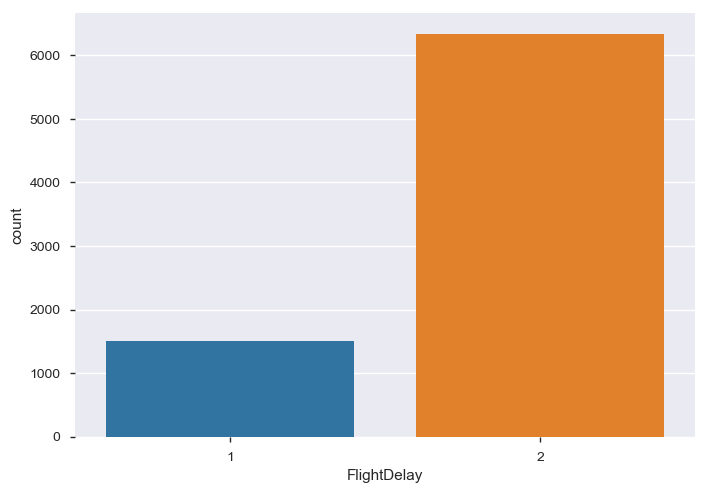

```python
import seaborn as sns
sns.countplot(x='FlightDelay',data=final_train7)
```

```python
#in %
(final_train7.FlightDelay.value_counts()/sum(final_train7.FlightDelay.value_counts()))*100
```

```
2    80.728106
1    19.271894
Name: FlightDelay, dtype: float64
```

```python
final_test7.shape
```

```
(6566, 61)
```

```python
final_train7.shape
```

```
(7856, 69)
```

```python
final_train7.columns
```

```
Index(['Unnamed: 0', 'FlightNumber', 'Year', 'Month', 'DayOfWeek',
       'ScheduledDepTime', 'ScheduledArrTime', 'ScheduledTravelTime', 'Origin',
       'Destination', 'Distance', 'ActualArrivalTimeStamp', 'Day', 'Date',
       'hours_x', 'Hours', 'WeatherStationID', 'AirportID', 'GroundHeight',
       'StationHeight', 'BarometerHeight', 'Latitude', 'Longitude', 'TimeZone',
       'YearMonthDay', 'Time', 'SkyConditions', 'Visibility', 'DBT',
       'DewPointTemp', 'RelativeHumidityPercent', 'WindSpeed', 'WindDirection',
       'WindGustValue', 'StationPressure', 'HourlyPrecip', 'hours_y', 'Ahours',
       'AHours', 'WeatherStationID1', 'AirportID1', 'GroundHeight1',
       'StationHeight1', 'BarometerHeight1', 'Latitude1', 'Longitude1',
       'TimeZone1', 'YearMonthDay1', 'Time1', 'SkyConditions1', 'Visibility1',
       'DBT1', 'DewPointTemp1', 'RelativeHumidityPercent1', 'WindSpeed1',
       'WindDirection1', 'WindGustValue1', 'StationPressure1', 'HourlyPrecip1',
       'Date1', 'hours1', 'Hours1', 'new_date', 'Scheduled_arrival',
       'Actual_ArrivalTime', 'ActualArrivalTimeStamp2', 'Actual_ArrivalTime2',
       'FlightDelay2', 'FlightDelay'],
      dtype='object')
```

variables to drop

```python
val1=['FlightNumber','Year','Month','DayOfWeek','ScheduledDepTime','ScheduledArrTime','ActualArrivalTimeStamp','Day','Date','hours_x','Hours','WeatherStationID','AirportID','Latitude','Longitude','TimeZone','YearMonthDay','Time','hours_y','Ahours','AHours','WeatherStationID1','AirportID1','Latitude1','Longitude1','TimeZone1','YearMonthDay1','Time1','Date1','hours1','Hours1','new_date','Scheduled_arrival','Actual_ArrivalTime','ActualArrivalTimeStamp2','Actual_ArrivalTime2','FlightDelay2']
```

```python
final_trainA=final_train7.drop(val1,axis=1)
```

```python
final_trainA.shape
```

```
(7856, 32)
```

```python
D=final_trainA.T
D
```

|  | 0 | 1 | 2 | 3 | 4 | 5 | 6 | 7 | 8 | 9 | ... | 7851 | 7852 | 7853 | 7854 | 7855 | 7856 | 7857 | 7858 | 7859 | 7860 |
| --- | --- | --- | --- | --- | --- | --- | --- | --- | --- | --- | --- | --- | --- | --- | --- | --- | --- | --- | --- | --- | --- |
| Unnamed: 0 | 0 | 4 | 5 | 7 | 8 | 9 | 10 | 11 | 12 | 13 | ... | 9415 | 9416 | 9417 | 9418 | 9419 | 9421 | 9422 | 9423 | 9424 | 9425 |
| ScheduledTravelTime | 114 | 114 | 62 | 93 | 76 | 62 | 107 | 63 | 120 | 156 | ... | 85 | 80 | 352 | 165 | 66 | 145 | 179 | 75 | 104 | 168 |
| Origin | BOS | CLE | SNA | CLT | MSP | CVG | DFW | ACV | BHM | DFW | ... | LEX | ORD | JFK | EWR | ATL | IAH | EWR | IAD | SLC | FLL |
| Destination | CLE | ATL | LAS | TPA | ORD | GRR | STL | SFO | DFW | PIT | ... | DCA | DTW | LAX | TPA | JAX | DEN | MEM | GSO | GEG | CLE |
| Distance | 563 | 554 | 226 | 508 | 334 | 268 | 551 | 250 | 597 | 1068 | ... | 414 | 235 | 2475 | 998 | 270 | 861 | 946 | 239 | 546 | 1062 |
| GroundHeight | 19 | 802 | 49 | 721 | 871 | 882 | 559 | 222 | 636 | 559 | ... | 977 | 655 | 29 | 25 | 971 | 118 | 25 | 306 | NaN | 117 |
| StationHeight | 30 | 805 | 55 | 769 | 838 | 883 | 596 | 210 | 630 | 596 | ... | 980 | 674 | 22 | 30 | 1026 | 108 | 30 | 323 | NaN | 11 |
| BarometerHeight | 180 | 805 | 52 | 724 | 874 | 885 | 562 | 225 | 639 | 562 | ... | 980 | 658 | 32 | 28 | 974 | 121 | 28 | 309 | NaN | 120 |
| SkyConditions | CLR | OVC022 | CLR | FEW045 | FEW065 SCT220 BKN250 | BKN250 | CLR | OVC013 | SCT022 BKN037 BKN090 | FEW090 BKN300 | ... | CLR | FEW041 SCT200 | FEW030 OVC036 | SCT035 | FEW045 SCT150 SCT250 | SCT018 BKN250 | BKN140 BKN250 | FEW050 | NaN | BKN035 OVC045 |
| Visibility | 10SM | 6SM | 7SM | 10SM | 10SM | 10SM | 10SM | 10SM | 10SM | 10SM | ... | 10SM | 10SM | 10SM | 10SM | 10SM | 10SM | 10SM | 9SM | NaN | 6SM |
| DBT | 63 | 53 | 69 | 90 | 68 | 72 | 80 | 58 | 74 | 79 | ... | 63 | 83 | 70 | 72 | 89 | 80 | 48 | 85 | NaN | 74 |
| DewPointTemp | 40 | 50 | 61 | 66 | 58 | 49 | 59 | 52 | 68 | 62 | ... | 54 | 65 | 57 | 59 | 71 | 72 | 26 | 60 | NaN | 73 |
| RelativeHumidityPercent | 43 | 89 | 76 | 45 | 70 | 44 | 49 | 81 | 82 | 56 | ... | 73 | 55 | 64 | 64 | 55 | 76 | 42 | 43 | NaN | 97 |
| WindSpeed | 6 | 7 | 7 | 0 | 10 | 7 | 14 | 0 | 11 | 3 | ... | 4 | 10 | 11 | 8 | 6 | 11 | 14 | 7 | NaN | 0 |
| WindDirection | 340 | 110 | 220 | 000 | 130 | 080 | 180 | 000 | 030 | 100 | ... | 200 | 320 | 110 | 110 | 330 | 210 | 330 | 310 | NaN | 000 |
| WindGustValue | 0 | 0 | 0 | 0 | 0 | 0 | 0 | 0 | 0 | 0 | ... | 0 | 0 | 0 | 0 | 0 | 16 | 18 | 0 | NaN | 0 |
| StationPressure | 30.28 | 29.21 | 29.82 | 29.26 | 29.02 | 29.14 | 29.43 | 29.8 | 29.25 | 29.51 | ... | 29.29 | 29.22 | 30.37 | 30.26 | 29.07 | 29.75 | 30.24 | 29.83 | NaN | 29.8 |
| HourlyPrecip | 0 | 0.01 | 0 | 0 | 0 | 0 | 0 | 0 | NaN | 0 | ... | 0 | 0 | 0 | 0 | 0 | 0 | 0 | 0 | NaN | 0.02 |
| GroundHeight1 | 802 | 971 | 2127 | 8 | 655 | 785 | 707 | 86 | 559 | 1172 | ... | 10 | 628 | 323 | 8 | 31 | 5379 | 283 | 904 | NaN | 802 |
| StationHeight1 | 805 | 1026 | 2180 | 11 | 674 | 803 | 710 | 18 | 596 | 1203 | ... | 65 | 664 | 326 | 11 | 32 | 5431 | 332 | 886 | NaN | 805 |
| BarometerHeight1 | 805 | 974 | 2091 | 40 | 658 | 788 | 710 | 89 | 562 | 1175 | ... | 3 | 631 | 326 | 40 | 34 | 5382 | 286 | 907 | NaN | 805 |
| SkyConditions1 | FEW250 | SCT007 BKN016 OVC050 | CLR | FEW035TCU OVC250 | FEW200 SCT250 | CLR | CLR | CLR | FEW080 | SCT040 | ... | BKN250 | FEW040 | SCT038 | FEW025 SCT070 SCT150 OVC250 | SCT045TCU | FEW080 SCT140 SCT220 | SCT060 BKN080 OVC150 | SCT060 | NaN | SCT250 |
| Visibility1 | 10SM | 2SM | 10SM | 10SM | 10SM | 10SM | 10SM | 9SM | 10SM | 10SM | ... | 10SM | 8SM | 10SM | 10SM | 10SM | 10SM | 10SM | 10SM | NaN | 10SM |
| DBT1 | 71 | NaN | 89 | 88 | 79 | 65 | 80 | 68 | 90 | 74 | ... | 71 | 78 | 77 | 82 | 95 | 71 | 62 | 83 | NaN | 57 |
| DewPointTemp1 | 35 | NaN | 25 | 76 | 55 | 45 | 60 | 55 | 56 | 56 | ... | 52 | 70 | 63 | 74 | 74 | 33 | 43 | 58 | NaN | 40 |
| RelativeHumidityPercent1 | 27 | NaN | 10 | 68 | 44 | 49 | 51 | 63 | 32 | 54 | ... | 51 | 76 | 62 | 77 | 51 | 25 | 50 | 43 | NaN | 53 |
| WindSpeed1 | 8 | 9 | 8 | 7 | 8 | 3 | 6 | 0 | 5 | 5 | ... | 3 | 0 | 10 | 20 | 7 | 18 | 8 | 9 | NaN | 8 |
| WindDirection1 | 190 | 150 | 190 | 010 | 200 | 020 | 220 | 000 | VRB | 070 | ... | 340 | 000 | 230 | 190 | 340 | 290 | 120 | 190 | NaN | 230 |
| WindGustValue1 | 0 | 0 | 0 | 0 | 0 | 0 | 0 | 0 | 0 | 0 | ... | 0 | 0 | 0 | 27 | 0 | 24 | 0 | 0 | NaN | 0 |
| StationPressure1 | 29.49 | NaN | 27.58 | 30.03 | 29.49 | 29.31 | 29.17 | 29.77 | 29.19 | 28.97 | ... | 30.31 | 29.21 | 29.43 | 29.63 | 30.01 | 24.51 | 29.66 | 29.21 | NaN | 28.96 |
| HourlyPrecip1 | 0 | NaN | 0 | 0 | 0 | 0 | 0 | 0 | 0 | 0 | ... | 0 | 0 | 0 | 0 | 0 | 0 | 0 | 0 | NaN | 0 |
| FlightDelay | 2 | 1 | 2 | 2 | 2 | 2 | 2 | 2 | 1 | 2 | ... | 2 | 2 | 2 | 1 | 2 | 2 | 2 | 2 | 2 | 1 |

32 rows × 7856 columns

```python
final_trainA.columns
```

```
Index(['Unnamed: 0', 'ScheduledTravelTime', 'Origin', 'Destination',
       'Distance', 'GroundHeight', 'StationHeight', 'BarometerHeight',
       'SkyConditions', 'Visibility', 'DBT', 'DewPointTemp',
       'RelativeHumidityPercent', 'WindSpeed', 'WindDirection',
       'WindGustValue', 'StationPressure', 'HourlyPrecip', 'GroundHeight1',
       'StationHeight1', 'BarometerHeight1', 'SkyConditions1', 'Visibility1',
       'DBT1', 'DewPointTemp1', 'RelativeHumidityPercent1', 'WindSpeed1',
       'WindDirection1', 'WindGustValue1', 'StationPressure1', 'HourlyPrecip1',
       'FlightDelay'],
      dtype='object')
```

```python
val2=['Year','Month','DayOfWeek','ScheduledDepTime','ScheduledArrTime','Day','Date','hours_x','Hours','WeatherStationID','AirportID','Latitude','Longitude','TimeZone','YearMonthDay','Time','hours_y','Ahours','AHours','WeatherStationID1','AirportID1','Latitude1','Longitude1','TimeZone1','YearMonthDay1','Time1','Date1','hours1','Hours1']
```

```python
final_test7.set_index('FlightNumber',inplace = True)
```

```python
final_test7.columns
```

```
Index(['Unnamed: 0', 'Year', 'Month', 'DayOfWeek', 'ScheduledDepTime',
       'ScheduledArrTime', 'ScheduledTravelTime', 'Origin', 'Destination',
       'Distance', 'Day', 'Date', 'hours_x', 'Hours', 'WeatherStationID',
       'AirportID', 'GroundHeight', 'StationHeight', 'BarometerHeight',
       'Latitude', 'Longitude', 'TimeZone', 'YearMonthDay', 'Time',
       'SkyConditions', 'Visibility', 'DBT', 'DewPointTemp',
       'RelativeHumidityPercent', 'WindSpeed', 'WindDirection',
       'WindGustValue', 'StationPressure', 'HourlyPrecip', 'hours_y', 'Ahours',
       'AHours', 'WeatherStationID1', 'AirportID1', 'GroundHeight1',
       'StationHeight1', 'BarometerHeight1', 'Latitude1', 'Longitude1',
       'TimeZone1', 'YearMonthDay1', 'Time1', 'SkyConditions1', 'Visibility1',
       'DBT1', 'DewPointTemp1', 'RelativeHumidityPercent1', 'WindSpeed1',
       'WindDirection1', 'WindGustValue1', 'StationPressure1', 'HourlyPrecip1',
       'Date1', 'hours1', 'Hours1'],
      dtype='object')
```

```python
final_testA=final_test7.drop(val2,axis=1)
```

```python
final_testA.shape
```

```
(6566, 31)
```

check nulls

```python
final_trainA.isnull().sum(axis=0)
```

```
Unnamed: 0                    0
ScheduledTravelTime           0
Origin                        0
Destination                   0
Distance                      0
GroundHeight                 96
StationHeight                96
BarometerHeight              96
SkyConditions               102
Visibility                  100
DBT                         214
DewPointTemp                215
RelativeHumidityPercent     216
WindSpeed                    98
WindDirection                98
WindGustValue                98
StationPressure             209
HourlyPrecip                725
GroundHeight1                90
StationHeight1               90
BarometerHeight1             90
SkyConditions1               93
Visibility1                  93
DBT1                        174
DewPointTemp1               175
RelativeHumidityPercent1    178
WindSpeed1                   92
WindDirection1               92
WindGustValue1               92
StationPressure1            172
HourlyPrecip1               644
FlightDelay                   0
dtype: int64
```

```python
final_trainA.describe(include='all').T
```

|  | count | unique | top | freq | mean | std | min | 25% | 50% | 75% | max |
| --- | --- | --- | --- | --- | --- | --- | --- | --- | --- | --- | --- |
| Unnamed: 0 | 7856 | NaN | NaN | NaN | 4726.15 | 2722.1 | 0 | 2374.75 | 4721 | 7118.5 | 9425 |
| ScheduledTravelTime | 7856 | NaN | NaN | NaN | 129.584 | 63.2668 | 61 | 83 | 112 | 155 | 562 |
| Origin | 7856 | 223 | ATL | 508 | NaN | NaN | NaN | NaN | NaN | NaN | NaN |
| Destination | 7856 | 215 | ATL | 621 | NaN | NaN | NaN | NaN | NaN | NaN | NaN |
| Distance | 7856 | NaN | NaN | NaN | 743.43 | 522.565 | 69 | 368 | 595 | 950 | 4962 |
| GroundHeight | 7760 | NaN | NaN | NaN | 810.353 | 1191.9 | 0 | 87 | 559 | 882 | 6674 |
| StationHeight | 7760 | NaN | NaN | NaN | 817.165 | 1201.84 | 0 | 68 | 596 | 883 | 6685 |
| BarometerHeight | 7760 | NaN | NaN | NaN | 816.289 | 1189.14 | 0 | 98 | 562 | 885 | 6677 |
| SkyConditions | 7754 | 3433 | CLR | 1006 | NaN | NaN | NaN | NaN | NaN | NaN | NaN |
| Visibility | 7756 | 20 | 10SM | 5696 | NaN | NaN | NaN | NaN | NaN | NaN | NaN |
| DBT | 7642 | NaN | NaN | NaN | 67.8031 | 15.4143 | 8 | 58 | 70 | 79 | 109 |
| DewPointTemp | 7641 | NaN | NaN | NaN | 52.5792 | 15.3824 | -4 | 43 | 56 | 65 | 80 |
| RelativeHumidityPercent | 7640 | NaN | NaN | NaN | 63.0563 | 21.5913 | 4 | 48 | 64 | 80 | 100 |
| WindSpeed | 7758 | NaN | NaN | NaN | 8.31065 | 4.74329 | 0 | 5 | 8 | 11 | 40 |
| WindDirection | 7758 | 38 | 000 | 551 | NaN | NaN | NaN | NaN | NaN | NaN | NaN |
| WindGustValue | 7758 | NaN | NaN | NaN | 2.91428 | 7.62428 | 0 | 0 | 0 | 0 | 55 |
| StationPressure | 7647 | NaN | NaN | NaN | 29.1844 | 1.22362 | 23.66 | 29.06 | 29.48 | 29.89 | 30.81 |
| HourlyPrecip | 7131 | NaN | NaN | NaN | 0.0117936 | 0.0756021 | 0 | 0 | 0 | 0 | 1.78 |
| GroundHeight1 | 7766 | NaN | NaN | NaN | 838.376 | 1204.36 | 0 | 89 | 559 | 904 | 6180 |
| StationHeight1 | 7766 | NaN | NaN | NaN | 847.319 | 1214.59 | 0 | 76 | 596 | 905 | 6535 |
| BarometerHeight1 | 7766 | NaN | NaN | NaN | 843.644 | 1201.41 | 0 | 120 | 562 | 907 | 6183 |
| SkyConditions1 | 7763 | 3435 | CLR | 1002 | NaN | NaN | NaN | NaN | NaN | NaN | NaN |
| Visibility1 | 7763 | 20 | 10SM | 6018 | NaN | NaN | NaN | NaN | NaN | NaN | NaN |
| DBT1 | 7682 | NaN | NaN | NaN | 68.9867 | 15.0459 | -21 | 59 | 71 | 80 | 108 |
| DewPointTemp1 | 7681 | NaN | NaN | NaN | 52.7637 | 15.2564 | -27 | 43 | 56 | 65 | 79 |
| RelativeHumidityPercent1 | 7678 | NaN | NaN | NaN | 61.1055 | 21.2456 | 4 | 47 | 62 | 77 | 100 |
| WindSpeed1 | 7764 | NaN | NaN | NaN | 8.29122 | 4.64414 | 0 | 5 | 8 | 11 | 34 |
| WindDirection1 | 7764 | 38 | 000 | 498 | NaN | NaN | NaN | NaN | NaN | NaN | NaN |
| WindGustValue1 | 7764 | NaN | NaN | NaN | 2.74948 | 7.40282 | 0 | 0 | 0 | 0 | 50 |
| StationPressure1 | 7684 | NaN | NaN | NaN | 29.1483 | 1.23298 | 23.69 | 29.04 | 29.44 | 29.87 | 30.85 |
| HourlyPrecip1 | 7212 | NaN | NaN | NaN | 0.00708403 | 0.0532871 | 0 | 0 | 0 | 0 | 1.78 |
| FlightDelay | 7856 | 2 | 2 | 6342 | NaN | NaN | NaN | NaN | NaN | NaN | NaN |

```python
val = {
'GroundHeight'            :    810.35,
'StationHeight'           :    817.165,
'BarometerHeight'         :    816.289,
'SkyConditions'           :   'CLR',
'Visibility'              :   '10',
'DBT'                     :    67,
'DewPointTemp'            :    52,
'RelativeHumidityPercent' :    63,
'WindSpeed'               :     8,
'WindDirection'           :  'VRB',
'WindGustValue'           :     3,
'StationPressure'           :  29,
'HourlyPrecip'              :   0,
'GroundHeight1'                :  838,
'StationHeight1'               :  847,
'BarometerHeight1'             :  843,
'SkyConditions1'               :  'CLR',
'Visibility1'                  :  '10SM',
'DBT1'                         : 68,
'DewPointTemp1'                : 52,
'RelativeHumidityPercent1'     : 61,
'WindSpeed1'                   :  8,
'WindDirection1'               :  'VRB',
'WindGustValue1'               :  2.7,
'StationPressure1'             :  29,
'HourlyPrecip1'                :   0,
}
final_trainA = final_trainA.fillna(val)
```